# The Primate Inner Ear Canal System

Dan Wawrzyniak

December 5, 2016

# Question

Do the size of the semicircular canals of the inner ear of primates correlate to postural and/or locomotor behaviour?

- Why do I care?
- Subarcuate fossa volume is positively correlated with increased body mass and increased canal volume (Jeffery et al. 2008)
- Humans and other great apes are weird: Have large canals but lack a true subarcuate fossa
- Hylobatids possess a true subarcuate fossa, but it is smaller than expected in relation to body size and canal size (Jeffery et al. 2008)
- Along with Hylobatids, spider monkeys (*Ateles geoffroyi*) are outliers
- Across mammals, size of the canals is positively correlated with faster, jerkier, more agile locomotion (Spoor et al. 2007)
- ….So, among primates (catarrhines), are the size of the semicircular canals correlated to postural and locomotor behaviours they employ?

# Jeffery et al. 2008

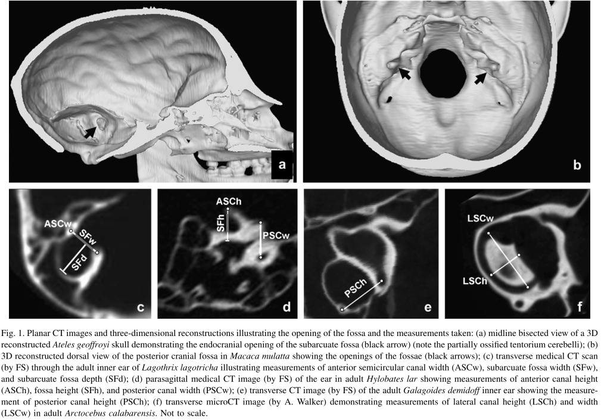

# Jeffery et al. 2008

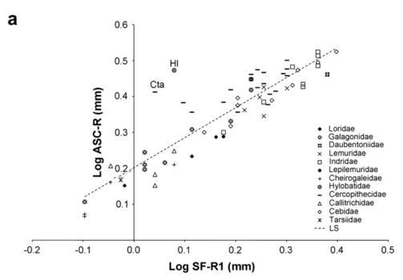

# Jeffery et al. 2008

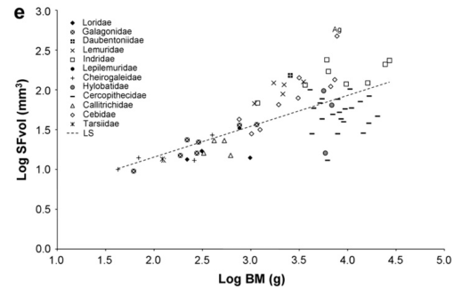

# Spoor et al. 2007

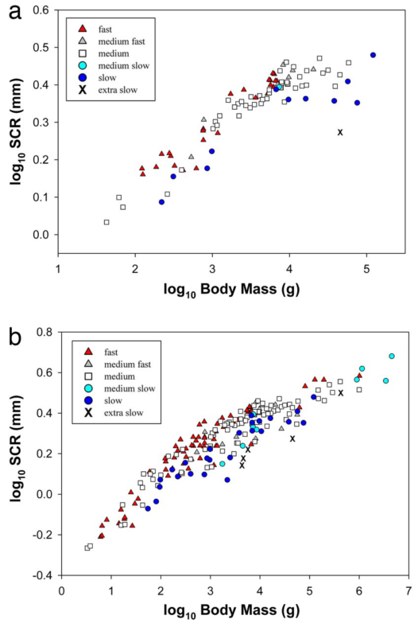

# Hunt 2016

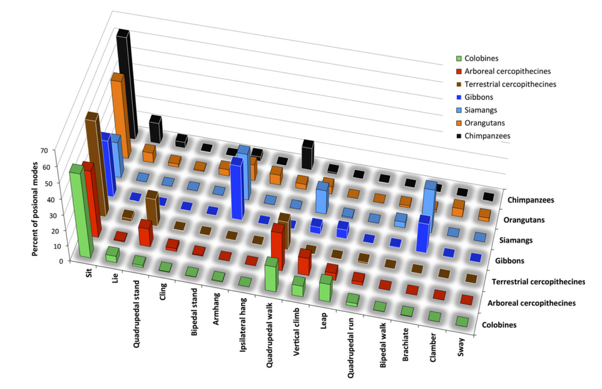

# Data

- Spoor et al. 2007 data on body mass and semicircular canals (using mean radius)
- Hunt 2016 data on primate behaviour
- Result: 24 species of Catarrhines
- Phylogenetic tree from 10k Trees (Consensus tree of 10,000 trees generated by Bayesian inference)

# Packages

```r
library(ape)

library(caper)

library(dplyr)

library(phytools)

library(gdata)

library(ggplot2)

library(pander)
```

# Data

Nexus phlyogenetic Tree

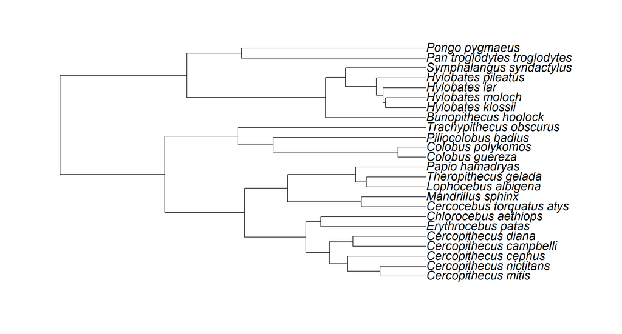

```r
Tree <- read.nexus("C_Tree.nex")

plot(Tree, cex = 1.5)
```

# Data

Behavioural Data

```r
Behaviour <- read.delim("Hunt_mod.tsv")
panderOptions('table.split.table', 300)
pander(Behaviour[1:4,])
```

| Species | Sit | Lie | Quad.Stand | Squat | Cling | Biped.Stand | Arm.Hang | Ipsilateral.Suspend | Quad.Walk | Vertical.Climb | Leap | Quad.Run | Bipedal.Walk | Brachiate | Clamber | Suspensory | Transfer | Sway |
| --- | --- | --- | --- | --- | --- | --- | --- | --- | --- | --- | --- | --- | --- | --- | --- | --- | --- | --- |
| Cercocebus atys | 52.3 | 0 | 10.2 | 0 | 1.2 | 0 | 0 | 0 | 28.5 | 4.4 | 0.4 | 2 | 0 | 0 | 0 | 0 | 0 | 0 |
| Cercopithecus aethiops | 68 | 0 | 12 | 0 | 0 | 0 | 0 | 0 | 17.3 | 0 | 0 | 2.7 | 0 | 0 | 0 | 0 | 0 | 0 |
| Cercopithecus campbelli | 41.4 | 0.6 | 12.8 | 0 | 2.8 | 0 | 0 | 0 | 30.2 | 6 | 2.2 | 3.2 | 0 | 0 | 0 | 0 | 0 | 0 |
| Cercopithecus cephus | 42.6 | 0.5 | 11.8 | 0 | 1.9 | 0.4 | 0 | 0 | 24.8 | 11.4 | 4.7 | 2 | 0 | 0 | 0 | 0 | 0 | 0 |

Semicircular Canals Data

```r
Canals <- read.delim("Spoor_mod.tsv")
panderOptions('table.split.table', 300)
pander(Canals[1:4,])
```

| Species | Group | BM..g | ASCR..mm | PSCR..mm | LSCR..mm | SCR..mm | logBM | logAGILITY | logASCR | logPSCR | logLSCR | logSCR |
| --- | --- | --- | --- | --- | --- | --- | --- | --- | --- | --- | --- | --- |
| Cercocebus atys | Arboreal Cercopith | 6200 | 2.6 | 2.4 | 2.4 | 2.5 | 3.792 | 0.778 | 0.412 | 0.385 | 0.386 | 0.394 |
| Cercopithecus aethiops | Arboreal Cercopith | 4099 | 2.4 | 2.4 | 2.3 | 2.3 | 3.613 | 0.602 | 0.38 | 0.377 | 0.355 | 0.371 |
| Cercopithecus campbelli | Arboreal Cercopith | 5100 | 2.3 | 2.3 | 2.3 | 2.3 | 3.708 | 0.602 | 0.366 | 0.359 | 0.364 | 0.363 |
| Cercopithecus cephus | Arboreal Cercopith | 4290 | 2.3 | 2.2 | 2.2 | 2.2 | 3.632 | 0.602 | 0.356 | 0.348 | 0.347 | 0.35 |

# Manipulating Data

- Combine
- Change seperator
- Change species names which don’t match in phylogeny
- Reorder data species according to phylogeny order
- comparative.data() to combine tree with data

```r
Canals <- Canals[,c(1,2,8,13)]

All_data <- left_join(Behaviour, Canals, by = "Species")

All_data$Species <- gsub(" ", "_", All_data$Species)

Tree$tip.label <- gsub("Cercocebus_torquatus_atys", "Cercocebus_atys", Tree$tip.label)

Tree$tip.label <- gsub("Bunopithecus_hoolock", "Hoolock_hoolock", Tree$tip.label)

Tree$tip.label <- gsub("Pan_troglodytes_troglodytes", "Pan_troglodytes", Tree$tip.label)

Tree$tip.label <- gsub("Chlorocebus_aethiops", "Cercopithecus_aethiops", Tree$tip.label)

All_data$Species <- reorder.factor(All_data$Species, new.order = Tree$tip.label)

All_data <- All_data %>% arrange(Species)

forPGLS <- comparative.data(phy = Tree, data = All_data, names.col = "Species")
```

# Scatterplot

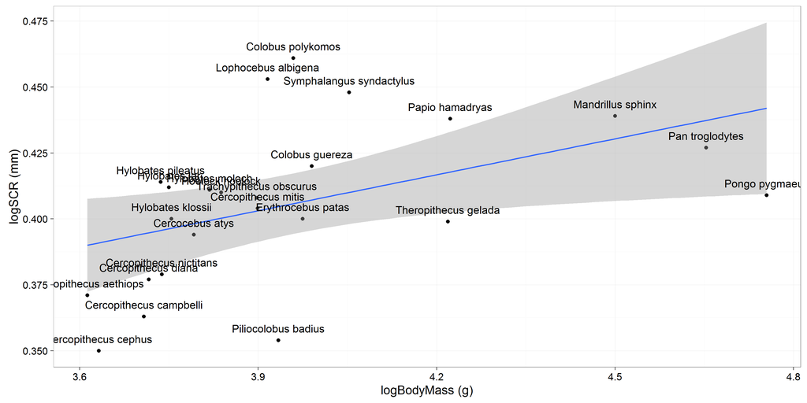

```r
ggplot(Canals, aes(x = logBM, y = logSCR, label = Species)) +
  geom_point(color = "black", size = 2.5) + geom_smooth(method ="lm") + geom_text(aes(label = Species),
  size = 6, hjust = .5, vjust = -1) +theme_bw(20) + labs(x= "logBodyMass (g)", y = "logSCR (mm)")
```

# Regression

OLS

```r
OLSmodel <- lm(logSCR ~ logBM, data = All_data)

anova(OLSmodel)
```

```
## Analysis of Variance Table
##
## Response: logSCR
##           Df    Sum Sq   Mean Sq F value  Pr(>F)
## logBM      1 0.0044682 0.0044682   6.073 0.02201 *
## Residuals 22 0.0161864 0.0007357
## ---
## Signif. codes:  0 '***' 0.001 '**' 0.01 '*' 0.05 '.' 0.1 ' ' 1
```

PGLS

```r
SCRpgls <- pgls( logSCR ~ logBM, data = forPGLS, lambda = "ML")

anova.pgls(SCRpgls)
```

```
## Analysis of Variance Table
## Sequential SS for pgls: lambda = 0.38, delta = 1.00, kappa = 1.00
##
## Response: logSCR
##           Df     Sum Sq    Mean Sq F value  Pr(>F)
## logBM      1 0.00014143 1.4143e-04  5.1215 0.03384 *
## Residuals 22 0.00060751 2.7614e-05
## ---
## Signif. codes:  0 '***' 0.001 '**' 0.01 '*' 0.05 '.' 0.1 ' ' 1
```

# Groups

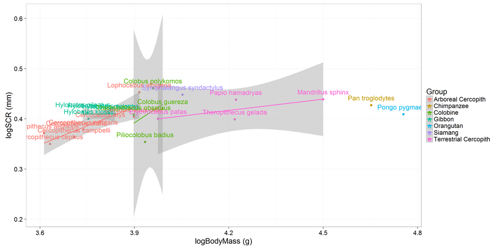

```r
ggplot(Canals, aes(x = logBM, y = logSCR, label = Species, color = Group)) +
  geom_point(size = 2.5) + geom_smooth(method ="lm") + geom_text(aes(label = Species),
  size = 6, hjust = .5, vjust = -1) + theme_bw(20) + labs(x= "logBodyMass (g)", y = "logSCR (mm)")
```

# ANCOVA

```r
OLSANCOVA <- lm(logSCR ~ logBM + Group, data = All_data)

anova(OLSANCOVA)
```

```
## Analysis of Variance Table
##
## Response: logSCR
##           Df    Sum Sq   Mean Sq F value  Pr(>F)
## logBM      1 0.0044682 0.0044682  7.3959 0.01515 *
## Group      6 0.0065201 0.0010867  1.7987 0.16279
## Residuals 16 0.0096663 0.0006041
## ---
## Signif. codes:  0 '***' 0.001 '**' 0.01 '*' 0.05 '.' 0.1 ' ' 1
```

# Multiple Regression

…but I have lots of continuous variables (18)

```r
panderOptions('table.split.table', 300)
pander(All_data[1:3, 1:19])
```

| Species | Sit | Lie | Quad.Stand | Squat | Cling | Biped.Stand | Arm.Hang | Ipsilateral.Suspend | Quad.Walk | Vertical.Climb | Leap | Quad.Run | Bipedal.Walk | Brachiate | Clamber | Suspensory | Transfer | Sway |
| --- | --- | --- | --- | --- | --- | --- | --- | --- | --- | --- | --- | --- | --- | --- | --- | --- | --- | --- |
| Cercopithecus_campbelli | 41.4 | 0.6 | 12.8 | 0 | 2.8 | 0 | 0 | 0 | 30.2 | 6 | 2.2 | 3.2 | 0 | 0 | 0 | 0 | 0 | 0 |
| Cercopithecus_cephus | 42.6 | 0.5 | 11.8 | 0 | 1.9 | 0.4 | 0 | 0 | 24.8 | 11.4 | 4.7 | 2 | 0 | 0 | 0 | 0 | 0 | 0 |
| Cercopithecus_diana | 32.9 | 0.6 | 12.2 | 0 | 8.4 | 0 | 0 | 0 | 26.6 | 10.7 | 5.7 | 6 | 0 | 0 | 0 | 0.1 | 0 | 0 |

# Multiple Regression

Creating the blank dataframe to store regression results

```r
Multreg <- data.frame(Dependent_Variable = character(),
                      Independent_Variable_1 = character(),
                      Independent_Variable_2 = character(),
                      Independent_Variable_3 = character(),
                      Independent_Variable_4 = character(),
                      Lambda = numeric(),
                      r_squared = numeric(),
                      p1 = numeric(),
                      p2 = numeric(),
                      p3 = numeric(),
                      p4 = numeric(),
                      Coefint = numeric(),
                      Coef1 = numeric(),
                      Coef2 = numeric(),
                      Coef3 = numeric(),
                      Coef4 = numeric(),
                      stringsAsFactors = FALSE)
```

# Multiple Regression

The first loop

```r
for(i in 2:19) {

    A <- lm( logSCR ~ logBM + All_data[ ,i], data = All_data )

    Multreg[length(Multreg$Dependent_Variable) + 1, ] <- c("logSCR", "logBM",
                                                  names(All_data[i]),
                                                  "NA", "NA", "NA",
                                                  summary(A)$adj.r.squared,
                                                  summary(A)$coefficients[2,4],
                                                  summary(A)$coefficients[3,4],
                                                  "NA", "NA", summary(A)$coefficients[1,1],
                                                  summary(A)$coefficients[2,1],
                                                  summary(A)$coefficients[3,1], "NA", "NA")
}
```

# Multiple Regression

First loop output

```r
panderOptions('table.split.table', 300)
pander(Multreg)
```

| Dependent_Variable | Independent_Variable_1 | Independent_Variable_2 | Independent_Variable_3 | Independent_Variable_4 | Lambda | r_squared | p1 | p2 | p3 | p4 | Coefint | Coef1 | Coef2 | Coef3 | Coef4 |
| --- | --- | --- | --- | --- | --- | --- | --- | --- | --- | --- | --- | --- | --- | --- | --- |
| logSCR | logBM | Sit | NA | NA | NA | 0.189854196313475 | 0.0129531473907321 | 0.276478023223858 | NA | NA | 0.207703290094453 | 0.0558733305086693 | -0.000509832674143418 | NA | NA |
| logSCR | logBM | Lie | NA | NA | NA | 0.15596108047673 | 0.142002843989876 | 0.557664003538595 | NA | NA | 0.258562434284621 | 0.0365684932666372 | 0.00139302734181822 | NA | NA |
| logSCR | logBM | Quad.Stand | NA | NA | NA | 0.370856508526095 | 0.00949320494356822 | 0.0115852829214208 | NA | NA | 0.235188164840687 | 0.0461671191992253 | -0.00134869919175839 | NA | NA |
| logSCR | logBM | Squat | NA | NA | NA | 0.291205568708661 | 0.0120206200807115 | 0.0475359137603683 | NA | NA | 0.221457368903962 | 0.0472462707631555 | -0.0155650360974206 | NA | NA |
| logSCR | logBM | Cling | NA | NA | NA | 0.270551110111965 | 0.0549862339742479 | 0.0677428146126311 | NA | NA | 0.266083641963218 | 0.0366032982617077 | -0.00594506521712025 | NA | NA |
| logSCR | logBM | Biped.Stand | NA | NA | NA | 0.217513344449473 | 0.00864668548801693 | 0.168429537483556 | NA | NA | 0.167409571148667 | 0.0610894677466927 | -0.0114766040875517 | NA | NA |
| logSCR | logBM | Arm.Hang | NA | NA | NA | 0.222351641393921 | 0.0120100477046916 | 0.154820333687067 | NA | NA | 0.201921861143129 | 0.0502184306139502 | 0.000518407529655307 | NA | NA |
| logSCR | logBM | Ipsilateral.Suspend | NA | NA | NA | 0.234180969896613 | 0.00675169886001672 | 0.126205594908552 | NA | NA | 0.153460568744308 | 0.064271680204366 | -0.00741815818613577 | NA | NA |
| logSCR | logBM | Quad.Walk | NA | NA | NA | 0.155370944110981 | 0.031597843262936 | 0.565993978273104 | NA | NA | 0.236990452848942 | 0.0437135625096809 | -0.000283032078932676 | NA | NA |
| logSCR | logBM | Vertical.Climb | NA | NA | NA | 0.24220176170668 | 0.00726832304337248 | 0.109975429726266 | NA | NA | 0.174481155426174 | 0.055954628342629 | 0.00158219870033696 | NA | NA |
| logSCR | logBM | Leap | NA | NA | NA | 0.14347676123869 | 0.0336748435622198 | 0.836355815430284 | NA | NA | 0.230986339341504 | 0.0444141426240311 | -0.000207417802785248 | NA | NA |
| logSCR | logBM | Quad.Run | NA | NA | NA | 0.236639113105257 | 0.0351745681409839 | 0.120984857134992 | NA | NA | 0.249795693138838 | 0.0406665119106997 | -0.00267059436142906 | NA | NA |
| logSCR | logBM | Bipedal.Walk | NA | NA | NA | 0.213826652871414 | 0.0203111372365292 | 0.179658946513945 | NA | NA | 0.228593300239865 | 0.0453846317731832 | -0.00305667162252644 | NA | NA |
| logSCR | logBM | Brachiate | NA | NA | NA | 0.257751997422434 | 0.00878267342227233 | 0.0843005658279843 | NA | NA | 0.195421900420471 | 0.0517071835805184 | 0.00113121937289576 | NA | NA |
| logSCR | logBM | Clamber | NA | NA | NA | 0.228181820981033 | 0.00740652176150534 | 0.139952233865852 | NA | NA | 0.155793579580007 | 0.0636528962249467 | -0.00760970786609672 | NA | NA |
| logSCR | logBM | Suspensory | NA | NA | NA | 0.235899813954066 | 0.00659103857697757 | 0.122531133416199 | NA | NA | 0.151491092530618 | 0.0649352135522576 | -0.0648686075565881 | NA | NA |
| logSCR | logBM | Transfer | NA | NA | NA | 0.235505140925675 | 0.0137843984541433 | 0.123364947766887 | NA | NA | 0.21055717548606 | 0.0481130761050985 | 0.0329176104634646 | NA | NA |
| logSCR | logBM | Sway | NA | NA | NA | 0.290833892208878 | 0.00293701092627973 | 0.047841086031005 | NA | NA | 0.137493334924821 | 0.0685690799243756 | -0.0204299730332003 | NA | NA |

# Multiple Regression

Preparing for Second Loop

```r
mycomb <- function(x) {
  sort(x) %>% paste(collapse = "-")
}

Check <- character()
Dupli <- logical()
```

Addresses the following issues:

- Duplicated runs (e.g. Quad.Stand-Suspensory, Suspensory-Quad.Stand)
- Errors in computing model because of many low/zero values

Both of the above speed up the loop run by eliminating unnecessary runs before they happen

# Multiple Regression

The Second Loop

```r
for(i in 2:19) {
  for(j in 2:19) {
    if(i != j) {
    Check[length(Check) + 1] <- mycomb(c(names(All_data[i]), names(All_data[j])))
    Dupli <- duplicated(Check)
    if(Dupli[length(Dupli)] == FALSE) {
      A <- lm( logSCR ~ logBM + All_data[ ,i] + All_data[ ,j], data = All_data )

      Multreg[length(Multreg$Dependent_Variable) + 1, ] <- c("logSCR", "logBM",
                                             names(All_data[i]),
                                             names(All_data[j]), "NA", "NA",
                                             summary(A)$adj.r.squared,
                                             summary(A)$coefficients[2,4],
                                             summary(A)$coefficients[3,4],
                                             summary(A)$coefficients[4,4],"NA",
                                             summary(A)$coefficients[1,1],
                                             summary(A)$coefficients[2,1],
                                             summary(A)$coefficients[3,1],
                                             summary(A)$coefficients[4,1], "NA")

    }
  }
  }
}
```

# Resulting Dataframe

```r
panderOptions('table.split.table', 300)
pander(Multreg[18:28,])
```

|  | Dependent_Variable | Independent_Variable_1 | Independent_Variable_2 | Independent_Variable_3 | Independent_Variable_4 | Lambda | r_squared | p1 | p2 | p3 | p4 | Coefint | Coef1 | Coef2 | Coef3 | Coef4 |
| --- | --- | --- | --- | --- | --- | --- | --- | --- | --- | --- | --- | --- | --- | --- | --- | --- |
| **18** | logSCR | logBM | Sway | NA | NA | NA | 0.290833892208878 | 0.00293701092627973 | 0.047841086031005 | NA | NA | 0.137493334924821 | 0.0685690799243756 | -0.0204299730332003 | NA | NA |
| **19** | logSCR | logBM | Sit | Lie | NA | NA | 0.191744709841832 | 0.0857726680427671 | 0.180063080141643 | 0.317940069804861 | NA | 0.260437824154414 | 0.0432813493057853 | -0.000668850654025933 | 0.00247565057508377 | NA |
| **20** | logSCR | logBM | Sit | Quad.Stand | NA | NA | 0.35269765048766 | 0.0112028020344168 | 0.528798514541368 | 0.0209364686251568 | NA | 0.225167390048241 | 0.051605925804942 | -0.000268623887414419 | -0.00127389384615413 | NA |
| **21** | logSCR | logBM | Sit | Squat | NA | NA | 0.306059581868725 | 0.0067233887901198 | 0.242662663405143 | 0.0462192982995423 | NA | 0.20348750615077 | 0.0576114090079579 | -0.000508441426638725 | -0.0155513795112138 | NA |
| **22** | logSCR | logBM | Sit | Cling | NA | NA | 0.296867939765373 | 0.0239884682129093 | 0.196422110952463 | 0.0538710265447442 | NA | 0.247835685347332 | 0.0477997190180847 | -0.000569430865459858 | -0.00622225111152244 | NA |
| **23** | logSCR | logBM | Sit | Biped.Stand | NA | NA | 0.264640532553726 | 0.00315454038779668 | 0.141283904860069 | 0.0918360752784862 | NA | 0.129685225415895 | 0.0786435007659109 | -0.000682350359004138 | -0.014153652215974 | NA |
| **24** | logSCR | logBM | Sit | Arm.Hang | NA | NA | 0.192613151178398 | 0.0156111553295041 | 0.639283683425595 | 0.312904444244056 | NA | 0.197499005349475 | 0.05440957595905 | -0.000247975211458463 | 0.000423822167183075 | NA |
| **25** | logSCR | logBM | Sit | Ipsilateral.Suspend | NA | NA | 0.266603877470855 | 0.00306199621559873 | 0.180206728958218 | 0.0889058618284855 | NA | 0.124209682406124 | 0.0786819172563609 | -0.000607653816056771 | -0.00821576808727109 | NA |
| **26** | logSCR | logBM | Sit | Quad.Walk | NA | NA | 0.155408220633522 | 0.0211586515554729 | 0.329037900416308 | 0.708786333897641 | NA | 0.21639059894864 | 0.0539960746540862 | -0.000475069149844173 | -0.000187402138503511 | NA |
| **27** | logSCR | logBM | Sit | Vertical.Climb | NA | NA | 0.20467016718384 | 0.013383933113761 | 0.925319941289692 | 0.252042874367866 | NA | 0.17350015511786 | 0.0553261778191079 | 6.29835127715897e-05 | 0.00168123076854003 | NA |
| **28** | logSCR | logBM | Sit | Leap | NA | NA | 0.161811464812894 | 0.0175663719746809 | 0.241123412439776 | 0.591537393500997 | NA | 0.219207199536987 | 0.0545371728957734 | -0.000584696772025512 | -0.000557965160291718 | NA |

# Multiple Regression

…and Finally…

```r
Check <- character()
Dupli <- logical()

for(i in 2:19) {
  for(j in 2:19) {
    if(i != j) {
      for(k in 2:19) {
        if(j != k) {
          if(i != k) {

    Check[length(Check) + 1] <- mycomb(c(names(All_data[i]), names(All_data[j]),
                                        names(All_data[k])))
    Dupli <- duplicated(Check)
    if(Dupli[length(Dupli)] == FALSE) {
    Try <- try(lm( logSCR ~ logBM + All_data[ ,i] + All_data[ ,j] +
                              All_data[ ,k], data = All_data ), silent = TRUE)
    if(class(Try) == "try-error") {
    }else{
    A <- lm( logSCR ~ logBM + All_data[ ,i] + All_data[ ,j] + All_data[ ,k],
                                                            data = All_data)
    if(length(anova(A)$Df) == 5) {
      Multreg[length(Multreg$Dependent_Variable) + 1, ] <- c("logSCR", "logBM",
              names(All_data[i]), names(All_data[j]), names(All_data[k]), "NA",
                        summary(A)$adj.r.squared, summary(A)$coefficients[2,4],
                    summary(A)$coefficients[3,4], summary(A)$coefficients[4,4],
                    summary(A)$coefficients[5,4], summary(A)$coefficients[1,1],
                    summary(A)$coefficients[2,1], summary(A)$coefficients[3,1],
                    summary(A)$coefficients[4,1], summary(A)$coefficients[5,1])
              } } } } } } } } }
```

# Resulting Dataframe

```r
panderOptions('table.split.table', 300)
pander(Multreg[300:310, 1:11])
```

|  | Dependent_Variable | Independent_Variable_1 | Independent_Variable_2 | Independent_Variable_3 | Independent_Variable_4 | Lambda | r_squared | p1 | p2 | p3 | p4 |
| --- | --- | --- | --- | --- | --- | --- | --- | --- | --- | --- | --- |
| **300** | logSCR | logBM | Sit | Brachiate | Transfer | NA | 0.183253505139773 | 0.0178178937290328 | 0.839428434037803 | 0.528389723423432 | 0.877139323965096 |
| **301** | logSCR | logBM | Sit | Brachiate | Sway | NA | 0.359766947715267 | 0.00148495740758758 | 0.554150688516071 | 0.189203218997941 | 0.0332527576162064 |
| **302** | logSCR | logBM | Sit | Clamber | Suspensory | NA | 0.23215693621627 | 0.00373216907682924 | 0.186480303822885 | 0.876631071744015 | 0.597747842747102 |
| **303** | logSCR | logBM | Sit | Clamber | Transfer | NA | 0.260322301795308 | 0.00611331348939597 | 0.442862301937341 | 0.135147756320371 | 0.324649451341537 |
| **304** | logSCR | logBM | Sit | Clamber | Sway | NA | 0.394070658793929 | 0.00147316699224724 | 0.129409284744251 | 0.0976501103961621 | 0.0308042736989624 |
| **305** | logSCR | logBM | Sit | Suspensory | Transfer | NA | 0.265838020947531 | 0.00567616735487626 | 0.419562894244571 | 0.123611614614185 | 0.355332763378309 |
| **306** | logSCR | logBM | Sit | Suspensory | Sway | NA | 0.322160417972473 | 0.00219533231610984 | 0.155085798832241 | 0.414040405009472 | 0.126732185090498 |
| **307** | logSCR | logBM | Sit | Transfer | Sway | NA | 0.326526365042641 | 0.00235998708379056 | 0.357049606412206 | 0.37507646637517 | 0.0463464503342091 |
| **308** | logSCR | logBM | Lie | Quad.Stand | Squat | NA | 0.307757787537393 | 0.0505066238740541 | 0.980403037506898 | 0.146950320496342 | 0.773137105025571 |
| **309** | logSCR | logBM | Lie | Quad.Stand | Cling | NA | 0.374403933127564 | 0.107879655277112 | 0.850110786784658 | 0.0416552255488528 | 0.161832118170509 |
| **310** | logSCR | logBM | Lie | Quad.Stand | Biped.Stand | NA | 0.443884810707157 | 0.00512149433219396 | 0.562407889994769 | 0.00444781019167357 | 0.0419450006663794 |

# Multiple Regression

Sort by r-squared to determine the models that explain the most variation

```r
Multreg[,6:16] <- apply(Multreg[,6:16], 2, as.numeric)

Multreg <- arrange(Multreg, desc(r_squared))

Multreg <- Multreg[1:10, ]

panderOptions('table.split.table', 300)
pander(Multreg)
```

| Dependent_Variable | Independent_Variable_1 | Independent_Variable_2 | Independent_Variable_3 | Independent_Variable_4 | Lambda | r_squared | p1 | p2 | p3 | p4 | Coefint | Coef1 | Coef2 | Coef3 | Coef4 |
| --- | --- | --- | --- | --- | --- | --- | --- | --- | --- | --- | --- | --- | --- | --- | --- |
| logSCR | logBM | Quad.Stand | Vertical.Climb | Suspensory | NA | 0.5784 | 9.567e-05 | 0.001797 | 0.09526 | 0.00571 | 0.08547 | 0.08343 | -0.001513 | 0.001266 | -0.09601 |
| logSCR | logBM | Quad.Stand | Biped.Stand | Vertical.Climb | NA | 0.5735 | 0.0001042 | 0.004594 | 0.006431 | 0.02195 | 0.0751 | 0.08504 | -0.001317 | -0.01932 | 0.001904 |
| logSCR | logBM | Quad.Stand | Vertical.Climb | Clamber | NA | 0.549 | 0.0001828 | 0.002928 | 0.1158 | 0.01148 | 0.09647 | 0.08028 | -0.001465 | 0.001228 | -0.01085 |
| logSCR | logBM | Squat | Clamber | Sway | NA | 0.549 | 0.0001194 | 0.005312 | 0.007155 | 0.007772 | -0.1193 | 0.1368 | -0.2997 | -0.6892 | 1.406 |
| logSCR | logBM | Squat | Ipsilateral.Suspend | Sway | NA | 0.549 | 0.0001194 | 0.005312 | 0.007155 | 0.007709 | -0.1193 | 0.1368 | -0.2997 | -0.7184 | 1.56 |
| logSCR | logBM | Squat | Ipsilateral.Suspend | Clamber | NA | 0.549 | 0.0001194 | 0.005312 | 0.007772 | 0.007709 | -0.1193 | 0.1368 | -0.2997 | 6.56 | -6.982 |
| logSCR | logBM | Quad.Stand | Ipsilateral.Suspend | Vertical.Climb | NA | 0.548 | 0.0001872 | 0.003244 | 0.01176 | 0.1178 | 0.09724 | 0.08006 | -0.001442 | -0.01016 | 0.001222 |
| logSCR | logBM | Quad.Stand | Suspensory | NA | NA | 0.5345 | 0.0002898 | 0.001112 | 0.008947 | NA | 0.13 | 0.07442 | -0.001641 | -0.09371 | NA |
| logSCR | logBM | Sit | Quad.Stand | Suspensory | NA | 0.5342 | 0.0003196 | 0.3332 | 0.002312 | 0.007952 | 0.1139 | 0.08238 | -0.0003542 | -0.001551 | -0.09632 |
| logSCR | logBM | Quad.Stand | Vertical.Climb | Sway | NA | 0.5338 | 0.0002563 | 0.009272 | 0.1388 | 0.01627 | 0.1067 | 0.07735 | -0.001238 | 0.001171 | -0.02078 |

# PGLS Regression for selected OLS models

```r
for(i in 1:10){
  l <- Multreg[i,3]
  m <- Multreg[i,4]
  n <- Multreg[i,5]
  if(Multreg[i,5] == "NA") {
    A <- pgls( logSCR ~ logBM + forPGLS$data[[l]] + forPGLS$data[[m]], data = forPGLS, lambda = "ML")
    Multreg[length(Multreg$Dependent_Variable) + 1, ] <- c("logSCR", "logBM", names(forPGLS$data[l]),
    names(forPGLS$data[m]), "NA", as.numeric(summary(A)$param.CI$lambda$opt),
    summary(A)$adj.r.squared, summary(A)$coefficients[2,4], summary(A)$coefficients[3,4],
    summary(A)$coefficients[4,4],"NA", summary(A)$coefficients[1,1],
    summary(A)$coefficients[2,1], summary(A)$coefficients[3,1], summary(A)$coefficients[4,1], "NA")
    } else {
    A <- pgls( logSCR ~ logBM + forPGLS$data[[l]] + forPGLS$data[[m]] + forPGLS$data[[n]] , data = forPGLS, lambda = "ML")
    Multreg[length(Multreg$Dependent_Variable) + 1, ] <- c("logSCR", "logBM", names(forPGLS$data[l]),
    names(forPGLS$data[m]), names(forPGLS$data[n]), as.numeric(summary(A)$param.CI$lambda$opt),
    summary(A)$adj.r.squared, summary(A)$coefficients[2,4], summary(A)$coefficients[3,4],
    summary(A)$coefficients[4,4], summary(A)$coefficients[5,4], summary(A)$coefficients[1,1],
    summary(A)$coefficients[2,1], summary(A)$coefficients[3,1], summary(A)$coefficients[4,1],
    summary(A)$coefficients[5,1])
    }
}
```